# Getting Started with R

2017-02-26

## Warming up

[figure not shown]

```r
15 * 7.7 # as a calculator
```

```
## [1] 115.5
```

```r
x <- 3 # assign to a variable.
y <- 10 # note the use of <- to assign
z <- 3:10
z * 3
```

```
## [1]  9 12 15 18 21 24 27 30
```

## Challenge

Find the square root of 1000.

Print only three decimal places.

```r
sqrt(1000)
```

```
## [1] 31.62278
```

```r
round(sqrt(1000), 3)
```

```
## [1] 31.623
```

## Basic stats

```r
a <- 1:10
b <- c(4,4,4,5,5,6,6,6,7,8)
c <- c(1,1,1,1,1,10,10,10,10,10)
mean(a) ; mean(b); mean(c)
```

```
## [1] 5.5
```

```
## [1] 5.5
```

```
## [1] 5.5
```

```r
sd(a) ; sd(b) ; sd(c)
```

```
## [1] 3.02765
```

```
## [1] 1.354006
```

```
## [1] 4.743416
```

## Directory Related Functions

### Finding your way within R

The concept of a working directory

`getwd() #get the current working directory`

`setwd() # Enter some other directory here, to make it the working directory`

Which files are in the directory? `list.files() # to search current directory`

To search some other directory: `dirpath <- "~/name/RStats"`

`dir(dirpath, full=TRUE)`

Your Turn: Which *.csv files are in the current directory?

Hint: `use ?list.files`

TIP: Create a directory to store all your R scripts in "RStats"

## How to get HELP in R?

```markdown
> ?<function name> # when you know the command
> ??<topic> # broader search
> help (command name)
> help (package=<packagename>)
??Binomial
help(Binomial)
```

### R Documentation has a strict set pattern

Description | Usage | Arguments | Value | Details | Reference | See Also | Examples

Tip: Most users start by looking at the examples

Important: You can cut-and-paste Examples from help directly into the console.

You can simply type it into the Help tab in RStudio

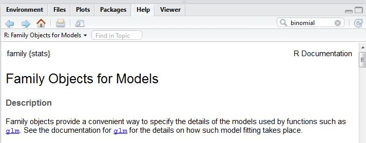

## Tip

> If you're not sure what type of value you are dealing with you can use `class`, or for more detailed information `str` (structure). Try the following:

> ```r
> class(myvec)
> class(mylist)
> str(mylist)
> ```

## vector

Vectors contain zero or more elements, *all of the same basic type* ("mode").

Elements can be named (`names`), but often aren't.

Access single elements: `vec[5]`

Take a subset of a vector: `vec[c(1,3,5)]` `vec[c(TRUE,FALSE,TRUE,FALSE,TRUE)]`

Vectors come in several different flavours.

## numeric vector

Numbers. Internally stored as "floating point" so there is a limit to the number of digits accuracy, but this is usually entirely adequate.

Examples: `42` `1e-3` `c(1,2,0.7)`

Casting: `as.numeric("42")`

## character vector

Character strings.

Examples: `"hello"` `c("Let","the","computer","do","the","work")`

Casting: `as.character(42)`

## logical vector

TRUE or FALSE values.

```
Examples: `TRUE` `FALSE` `T` `F` `c(TRUE,FALSE,TRUE)`
```

## factor vector

A categorical vector, where the elements can be one of several different "levels". There will be more on these in the chapter on data frames.

Creation/casting: `factor(c("mutant","wildtype","mutant"), levels=c("wildtype","mutant"))`

## list

Lists contain zero or more elements, of any type. Elements of a list can even be vectors with their own multiple elements, or other lists. If your data can't be bundled up in any other type, bundle it up in a list.

List elements can and typically do have names (`names`).

Access an element: `mylist[[5]]` `mylist[["elementname"]]` `mylist$elementname`

Creation: `list(a=1, b="two", c=FALSE)`

## data.frame

A data frame is a two dimensional tabular data structure in which the columns may have different types, but all the elements in each column must have the same type.

Accessing elements, rows, and columns is the same as for matrices, but we can also get a whole column using `$`.

Creation: `data.frame(colname1=values1,colname2=values2,...)`

Casting: `as.data.frame( )`